# salmon_group17

Kat Leigh, Teague Tran, Lucas Empson

1/29/2021

# A Decade of Fish Passage at the Willamette Falls Fish Ladder

## Overview:

This dataset was recorded from 2001-01-01 to 2010-12-31 at the Willamette Falls fish ladder on the Willamette River in Oregon, and can be accessed from [Columbia River DART](http://www.cbr.washington.edu/dart/query/adult_graph_text) (Data Access in Real Time). It contains daily per species counts of adult fish that passed through the ladder along with water temperature measurements. This document focuses on three species (coho, jack coho, and steelhead), and explores changes over time, both seasonally and annually.

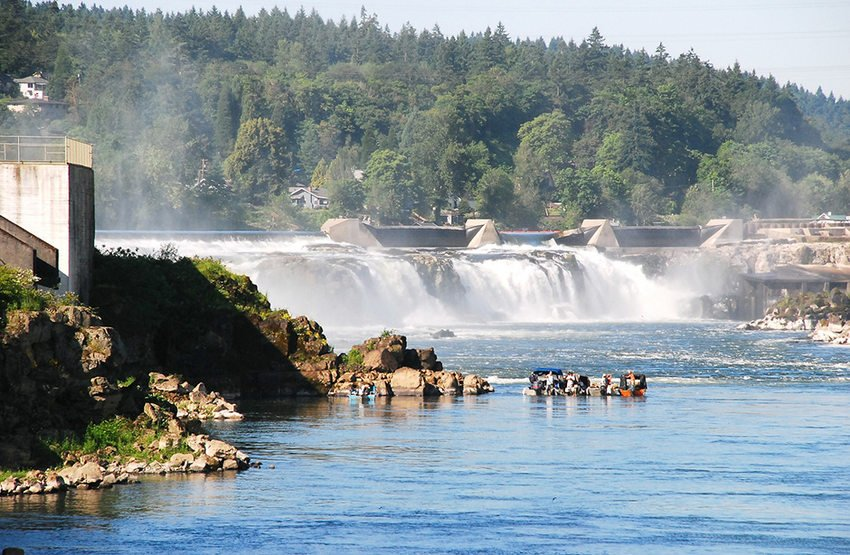

Image of Willamette Falls (Source: [Metro Council](https://www.oregonmetro.gov/))

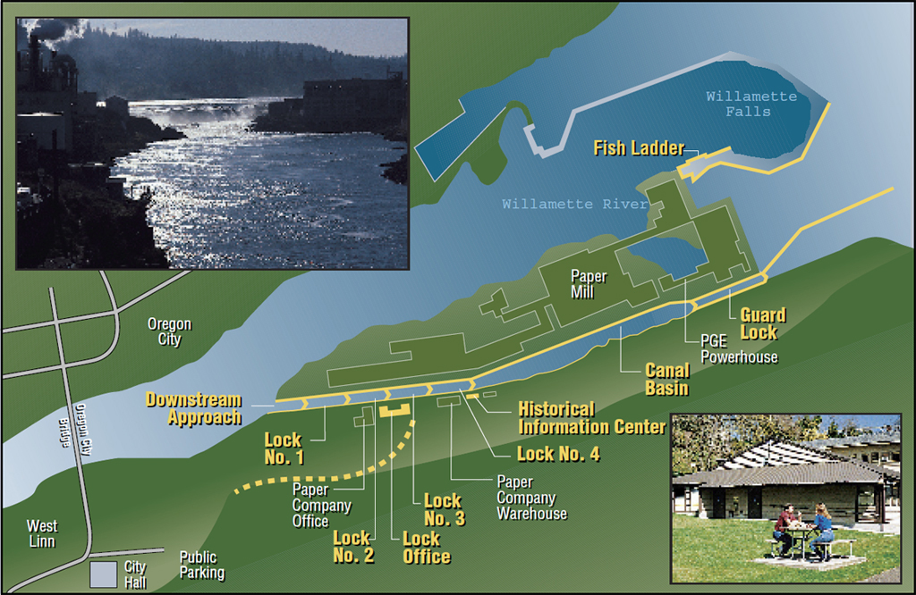

Map of Willamette Falls within Oregon City, OR. (Source: [U.S. Army Corp. of Engineers](https://www.nwp.usace.army.mil/willamette/locks/))

# Main Content

## Tab 1: Original time series

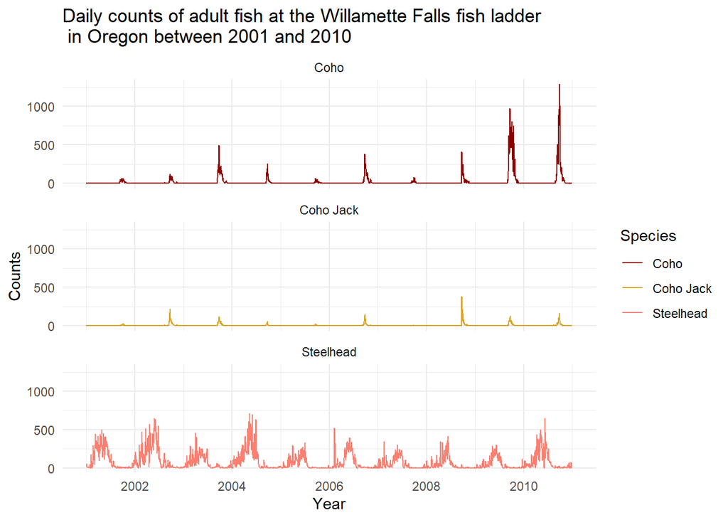

Figure 1. Two species depicted *Oncorhynchus kisutch* (Coho and Jack coho), and *Oncorhynchus mykiss* (Steelhead). Note: ‘jack’ refers to precotial males that have spent one winter less in the ocean than the youngest females. Coho jacks return to spawn the same year they smolted.

```r
# get data
fish_raw <- read.csv(here("data", "willamette_fish_passage.csv")) %>% clean_names()

# select species, replace NAs, and convert dates
three_spec <- fish_raw %>%
  select(date, coho, jack_coho, steelhead) %>%
  mutate(coho = ifelse(is.na(coho), 0, coho),
         jack_coho = ifelse(is.na(jack_coho), 0, jack_coho),
         steelhead = ifelse(is.na(steelhead), 0, steelhead)) %>%
  mutate(date = lubridate::mdy(date)) %>%
  group_by(date)%>%
  as_tsibble(key = NULL, index = date)

# put species into 1 column
longer_3_spec <- three_spec %>%
  select(date, coho, jack_coho, steelhead) %>%
  gather(key = "Species", value = "count", -date) %>%
  mutate(Species = ifelse(Species == "coho", "Coho",
                          ifelse(Species == "jack_coho", "Coho Jack",
                                 ifelse(Species == "steelhead", "Steelhead", 0)))) %>%
  mutate(Species = as.factor(Species)) %>%
  ungroup()


# plot the data with 3 facets
graph_3_spec <- ggplot(longer_3_spec, aes(x = date, y = count)) +
  geom_line(aes(color = Species)) +
  scale_color_manual(values = c("darkred", "goldenrod", "salmon"))+
  theme_minimal()+
  facet_wrap(~Species, ncol = 1)+
  labs(title = "Daily counts of adult fish at the Willamette Falls fish ladder\n in Oregon between 2001 and 2010",
       x= "Year",
       y= "Counts")+
  theme(plot.caption = element_textbox_simple(vjust = 1.5))

graph_3_spec
```

- all categories show seasonality, with Jack coho closely mirroring (with smaller maximums) the patterns of Coho.
- Coho salmon counts reached a larger maximum than Jack coho or Steelhead, and grew markedly in years 2009 and 2010.
- average Steelhead counts generally exceed that of Coho and Jack coho.

## Tab 2: Seasonplots

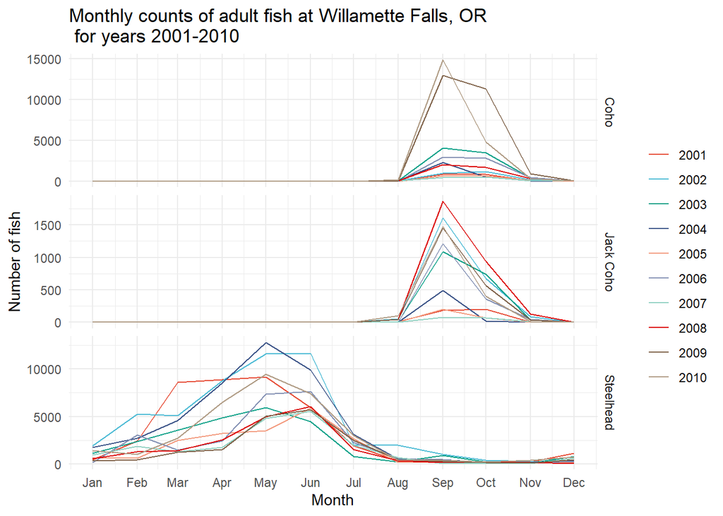

Figure 2. Monthly counts of *Oncorhynchus kisutch* (Coho and Jack Coho), and *Oncorhynchus mykiss* (Steelhead) at Willamette Falls, OR from 2001-2010. Data: Columbia River DART (Data Access in Real Time).

```r
# Select Coho, Jack Coho, and Steelhead from fish data set; convert date to date with 'mdy' format; convert data frame to tsibble
salmon_ts <- fish_raw %>%
  select(project, date, coho, jack_coho, steelhead) %>%
  mutate(date = lubridate::mdy(date)) %>%
  as_tsibble(key = NULL, index = date)


# `index_by()` to aggregate by year/month; calculate total count by species, per time increment
salmon_monthly <- salmon_ts %>%
  index_by(yr_mo = ~yearmonth(.)) %>%
  summarize(Coho = sum(coho, na.rm =TRUE),
            "Jack Coho" = sum(jack_coho, na.rm =TRUE),
            Steelhead = sum(steelhead, na.rm =TRUE)) %>%
  gather("species", "monthly_total", -yr_mo)

# Seasonplot of monthly counts by year for Coho, Jack Coho, and Steelhead
salmon_monthly %>%
  gg_season(y = monthly_total, pal = pal_npg()(10)) +
    theme_minimal() +
  labs(x = "Month", y = "Number of fish", title = "Monthly counts of adult fish at Willamette Falls, OR\n for years 2001-2010")
```

- Coho and Jack Coho show very similar seasonality, with greatest observed adult fish counts generally occuring in September
- Adult Steelhead counts are greatest during Spring (March-June)

## Tab 3: Summary statistics and analysis

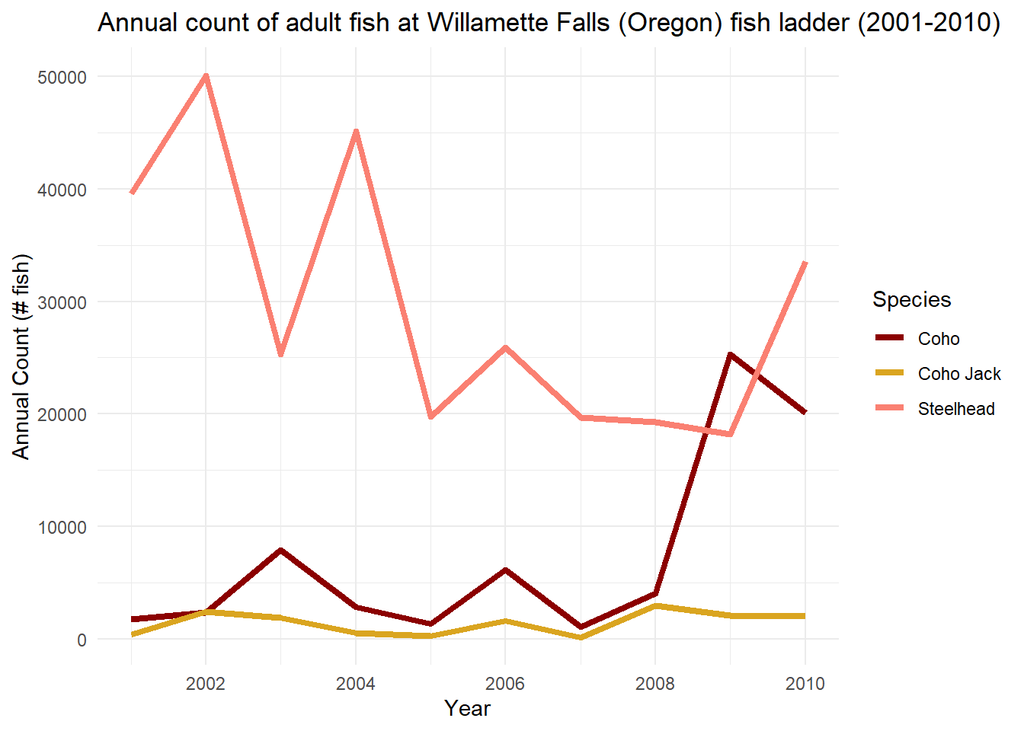

Figure 3. Total counts of fish passages of *Oncorhynchus kisutch* (Coho and Jack coho), and *Oncorhynchus mykiss* (Steelhead). Note: ‘jack’ refers to precotial males that have spent one winter less in the ocean than the youngest females. Coho jacks return to spawn the same year they smolted.

```r
#select species, replace NAs and convert dates without messing with my partners' information
salmonids <- fish_raw %>%
  select(date, coho, jack_coho, steelhead) %>%
  mutate(coho = ifelse(is.na(coho), 0, coho),
         jack_coho = ifelse(is.na(jack_coho), 0, jack_coho),
         steelhead = ifelse(is.na(steelhead), 0, steelhead)) %>%
  mutate(date = lubridate::mdy(date)) %>%
  group_by(date)%>%
  as_tsibble(key = NULL, index = date)

#put all fish into one column
total_salmonids <- salmonids %>%
  select(date, coho, jack_coho, steelhead) %>%
  gather(key = "Species", value = "count", -date) %>%
  mutate(Species = ifelse(Species == "coho", "Coho",
                          ifelse(Species == "jack_coho", "Coho Jack",
                                 ifelse(Species == "steelhead", "Steelhead", 0)))) %>%
  mutate(Species = as.factor(Species)) %>%
  ungroup()

#group by species, index by years to be able to input data into graph

salmonids_year <- total_salmonids %>%
  group_by(Species) %>%
  index_by(year = ~year(.)) %>%
  summarize(annual_count = sum(count))

#graph the three types of fish
annual_salmonids_graph <- ggplot(data = salmonids_year, aes(x = year, y = annual_count, color = Species)) +
  geom_line(size = 1.5) +
  scale_color_manual(values = c("darkred", "goldenrod", "salmon")) +
  labs(x = "Year", y = "Annual Count (# fish)", title = "Annual count of adult fish at Willamette Falls (Oregon) fish ladder (2001-2010)" ) +
  theme_minimal()+
  scale_x_continuous(breaks = pretty_breaks( n = 5))
#display graph

annual_salmonids_graph
```

- Steelhead annual passage counts have declined since 2001 (declining trend)
- Coho annual passage counts have increased since 2001 (inclining trend)
- Coho Jack counts have been relatively low and constant compare to adult, non-jack Coho and Steelhead